# Machine Learning Course Project

Pixel

Tuesday, November 17, 2015

## Background

Using devices such as Jawbone Up, Nike FuelBand, and Fitbit it is now possible to collect a large amount of data about personal activity relatively inexpensively. These type of devices are part of the quantified self movement - a group of enthusiasts who take measurements about themselves regularly to improve their health, to find patterns in their behavior, or because they are tech geeks. One thing that people regularly do is quantify how much of a particular activity they do, but they rarely quantify how well they do it. In this project, your goal will be to use data from accelerometers on the belt, forearm, arm, and dumbell of 6 participants. They were asked to perform barbell lifts correctly and incorrectly in 5 different ways. More information is available from the website here: http://groupware.les.inf.puc-rio.br/har (see the section on the Weight Lifting Exercise Dataset).

Source : http://groupware.les.inf.puc-rio.br/har Velloso, E.; Bulling, A.; Gellersen, H.; Ugulino, W.; Fuks, H. Qualitative Activity Recognition of Weight Lifting Exercises. Proceedings of 4th International Conference in Cooperation with SIGCHI (Augmented Human ’13) . Stuttgart, Germany: ACM SIGCHI, 2013.

*Read more: http://groupware.les.inf.puc-rio.br/har#ixzz3rmmb2yKx*

**Libraries used**

```r
library(caret)
library(AppliedPredictiveModeling)
library(rpart)
library(rattle)
library(randomForest)
```

## 1.Loading data

First we load the training and test data from the 2 files with url links.

```r
trainSet01 <- read.csv(url("http://d396qusza40orc.cloudfront.net/predmachlearn/pml-training.csv"), na.strings = c("NA","#DIV/0!",""))
testSet01 <- read.csv(url("http://d396qusza40orc.cloudfront.net/predmachlearn/pml-testing.csv"), na.strings = c("NA","#DIV/0!",""))
```

## 2.Data discovery

We take a first look at our data to see what’s coming.

```r
summary(trainSet01)
```

```
##        X            user_name    raw_timestamp_part_1 raw_timestamp_part_2
##  Min.   :    1   adelmo  :3892   Min.   :1.322e+09    Min.   :   294
##  1st Qu.: 4906   carlitos:3112   1st Qu.:1.323e+09    1st Qu.:252912
##  Median : 9812   charles :3536   Median :1.323e+09    Median :496380
##  Mean   : 9812   eurico  :3070   Mean   :1.323e+09    Mean   :500656
##  3rd Qu.:14717   jeremy  :3402   3rd Qu.:1.323e+09    3rd Qu.:751891
##  Max.   :19622   pedro   :2610   Max.   :1.323e+09    Max.   :998801
##
##           cvtd_timestamp  new_window    num_window      roll_belt
##  28/11/2011 14:14: 1498   no :19216   Min.   :  1.0   Min.   :-28.90
##  05/12/2011 11:24: 1497   yes:  406   1st Qu.:222.0   1st Qu.:  1.10
##  30/11/2011 17:11: 1440               Median :424.0   Median :113.00
##  05/12/2011 11:25: 1425               Mean   :430.6   Mean   : 64.41
##  02/12/2011 14:57: 1380               3rd Qu.:644.0   3rd Qu.:123.00
##  02/12/2011 13:34: 1375               Max.   :864.0   Max.   :162.00
##  (Other)         :11007
##    pitch_belt          yaw_belt       total_accel_belt kurtosis_roll_belt
##  Min.   :-55.8000   Min.   :-180.00   Min.   : 0.00    Min.   :-2.121
##  1st Qu.:  1.7600   1st Qu.: -88.30   1st Qu.: 3.00    1st Qu.:-1.329
##  Median :  5.2800   Median : -13.00   Median :17.00    Median :-0.899
##  Mean   :  0.3053   Mean   : -11.21   Mean   :11.31    Mean   :-0.220
##  3rd Qu.: 14.9000   3rd Qu.:  12.90   3rd Qu.:18.00    3rd Qu.:-0.219
##  Max.   : 60.3000   Max.   : 179.00   Max.   :29.00    Max.   :33.000
##                                                        NA's   :19226
##  kurtosis_picth_belt kurtosis_yaw_belt skewness_roll_belt
##  Min.   :-2.190      Mode:logical      Min.   :-5.745
##  1st Qu.:-1.107      NA's:19622        1st Qu.:-0.444
##  Median :-0.151                        Median : 0.000
##  Mean   : 4.334                        Mean   :-0.026
##  3rd Qu.: 3.178                        3rd Qu.: 0.417
##  Max.   :58.000                        Max.   : 3.595
##  NA's   :19248                         NA's   :19225
##  skewness_roll_belt.1 skewness_yaw_belt max_roll_belt     max_picth_belt
##  Min.   :-7.616       Mode:logical      Min.   :-94.300   Min.   : 3.00
##  1st Qu.:-1.114       NA's:19622        1st Qu.:-88.000   1st Qu.: 5.00
##  Median :-0.068                         Median : -5.100   Median :18.00
##  Mean   :-0.296                         Mean   : -6.667   Mean   :12.92
##  3rd Qu.: 0.661                         3rd Qu.: 18.500   3rd Qu.:19.00
##  Max.   : 7.348                         Max.   :180.000   Max.   :30.00
##  NA's   :19248                          NA's   :19216     NA's   :19216
```

[output cut: 313 more lines]

```
##  Min.   :-446.00   Min.   :-1280.0   Min.   :-896.0   Min.   :-973.0
##  1st Qu.:-182.00   1st Qu.: -616.0   1st Qu.:   2.0   1st Qu.: 191.0
##  Median : -39.00   Median : -378.0   Median : 591.0   Median : 511.0
##  Mean   : -55.29   Mean   : -312.6   Mean   : 380.1   Mean   : 393.6
##  3rd Qu.:  26.00   3rd Qu.:  -73.0   3rd Qu.: 737.0   3rd Qu.: 653.0
##  Max.   : 291.00   Max.   :  672.0   Max.   :1480.0   Max.   :1090.0
##
##  classe
##  A:5580
##  B:3797
##  C:3422
##  D:3216
##  E:3607
##
##
```

We can observ that some columns of our data set are filled with NA values.

## 3.Cleaning data

Because of NA values in the data set, we now subset this columns from our training and testing set.

```r
trainSet02 <- trainSet01[,colSums(is.na(trainSet01)) == 0]
testSet02 <- testSet01[,colSums(is.na(testSet01)) == 0]
```

Obviously, there a few columns at the beginning of the file that doesn’t seem relevant for our modelisation, such as ID of the record (X), user name, or time stamp. So we take back this columns from the data set. We only maintain our data from the 8th column (roll_belt).

```r
trainSet03 <- trainSet02[,-c(1:7)]
testSet03 <- testSet02[,-c(1:7)]
```

## 4.Modelisation

Now, we focus on the training set (trainSet03). TO make our model reproducible, we set the seed.

```r
set.seed(201281)
```

In order to make a cross validation of our model, we split the training set into a training and a test set.

```r
trainingSplit = createDataPartition(y = trainSet03$classe,
                                    p = 0.75, list=FALSE)
trainingSet = trainSet03[ trainingSplit,]
testingSet = trainSet03[-trainingSplit,]
dim(trainingSet); dim(testingSet)
```

```
## [1] 14718    53
```

```
## [1] 4904   53
```

We are now going to try 2 different modelisation in order to optimize accuracy of our prediction. Because of their accuracy, we’ll try decision tree and random forest modelisation.

First, we are going to make a decision tree and take a look at the final model.

```r
treeModel <- rpart(classe ~ ., data = trainingSet, method = "class")
print(treeModel)
```

```
## n= 14718
##
## node), split, n, loss, yval, (yprob)
##       * denotes terminal node
##
##     1) root 14718 10533 A (0.28 0.19 0.17 0.16 0.18)
##       2) roll_belt< 130.5 13466  9295 A (0.31 0.21 0.19 0.18 0.11)
##         4) pitch_forearm< -33.95 1182     8 A (0.99 0.0068 0 0 0) *
##         5) pitch_forearm>=-33.95 12284  9287 A (0.24 0.23 0.21 0.2 0.12)
##          10) magnet_dumbbell_y< 439.5 10364  7429 A (0.28 0.18 0.24 0.19 0.11)
##            20) roll_forearm< 122.5 6434  3808 A (0.41 0.18 0.18 0.17 0.063)
##              40) magnet_dumbbell_z< -27.5 2193   727 A (0.67 0.21 0.013 0.077 0.031)
##                80) roll_forearm>=-136.5 1814   384 A (0.79 0.17 0.014 0.023 0.005) *
##                81) roll_forearm< -136.5 379   225 B (0.095 0.41 0.011 0.33 0.16) *
##              41) magnet_dumbbell_z>=-27.5 4241  3081 A (0.27 0.16 0.27 0.22 0.08)
##                82) yaw_belt>=169.5 506    51 A (0.9 0.042 0 0.059 0) *
##                83) yaw_belt< 169.5 3735  2587 C (0.19 0.18 0.31 0.24 0.09)
##                 166) accel_dumbbell_y>=-40.5 3227  2361 D (0.22 0.2 0.22 0.27 0.098)
##                   332) pitch_belt< -42.95 377    77 B (0.027 0.8 0.11 0.042 0.024) *
##                   333) pitch_belt>=-42.95 2850  2000 D (0.24 0.12 0.23 0.3 0.11)
##                     666) roll_belt>=125.5 676   288 C (0.38 0.027 0.57 0.015 0.0044)
##                      1332) magnet_belt_z< -322.5 233     9 A (0.96 0 0.026 0 0.013) *
##                      1333) magnet_belt_z>=-322.5 443    61 C (0.074 0.041 0.86 0.023 0) *
##                     667) roll_belt< 125.5 2174  1334 D (0.2 0.15 0.13 0.39 0.14)
##                      1334) pitch_belt>=1.04 1407  1087 D (0.22 0.21 0.14 0.23 0.2)
##                        2668) yaw_forearm>=-99.15 1116   800 A (0.28 0.25 0.13 0.1 0.23)
##                          5336) accel_dumbbell_z< 21.5 629   338 A (0.46 0.18 0.24 0.094 0.03)
##                           10672) magnet_forearm_z>=-184.5 425   137 A (0.68 0.14 0.019 0.12 0.04) *
##                           10673) magnet_forearm_z< -184.5 204    64 C (0.015 0.25 0.69 0.034 0.0098) *
##                          5337) accel_dumbbell_z>=21.5 487   247 E (0.051 0.34 0.0021 0.11 0.49) *
##                        2669) yaw_forearm< -99.15 291    84 D (0 0.055 0.18 0.71 0.058) *
##                      1335) pitch_belt< 1.04 767   247 D (0.15 0.031 0.1 0.68 0.037)
##                        2670) yaw_arm< -96.6 108     0 A (1 0 0 0 0) *
##                        2671) yaw_arm>=-96.6 659   139 D (0.014 0.036 0.12 0.79 0.042) *
##                 167) accel_dumbbell_y< -40.5 508    68 C (0.0098 0.045 0.87 0.035 0.043) *
##            21) roll_forearm>=122.5 3930  2619 C (0.079 0.18 0.33 0.23 0.18)
##              42) magnet_dumbbell_y< 290.5 2310  1178 C (0.093 0.14 0.49 0.14 0.13)
##                84) magnet_forearm_z< -245.5 172    32 A (0.81 0.064 0 0.023 0.099) *
##                85) magnet_forearm_z>=-245.5 2138  1006 C (0.035 0.15 0.53 0.15 0.14)
##                 170) pitch_belt>=26.15 156    26 B (0.096 0.83 0.019 0 0.051) *
##                 171) pitch_belt< 26.15 1982   853 C (0.03 0.091 0.57 0.16 0.14) *
##              43) magnet_dumbbell_y>=290.5 1620  1064 D (0.059 0.25 0.11 0.34 0.24)
##                86) accel_forearm_x>=-79.5 965   634 E (0.056 0.31 0.16 0.13 0.34)
##                 172) magnet_arm_y>=185.5 393   181 B (0.018 0.54 0.24 0.089 0.11) *
##                 173) magnet_arm_y< 185.5 572   286 E (0.082 0.15 0.1 0.16 0.5) *
##                87) accel_forearm_x< -79.5 655   228 D (0.063 0.15 0.041 0.65 0.092) *
##          11) magnet_dumbbell_y>=439.5 1920   944 B (0.032 0.51 0.041 0.23 0.19)
##            22) total_accel_dumbbell>=5.5 1355   462 B (0.046 0.66 0.058 0.015 0.22)
##              44) roll_belt>=-0.575 1148   255 B (0.054 0.78 0.068 0.017 0.083) *
##              45) roll_belt< -0.575 207     0 E (0 0 0 0 1) *
##            23) total_accel_dumbbell< 5.5 565   142 D (0 0.15 0.0018 0.75 0.1) *
##       3) roll_belt>=130.5 1252    14 E (0.011 0 0 0 0.99) *
```

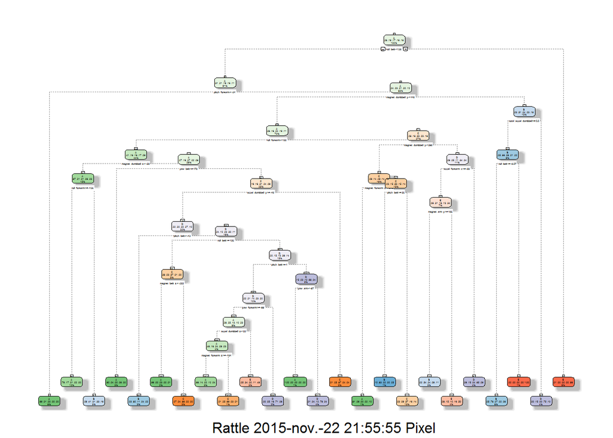

```r
fancyRpartPlot(treeModel)
```

We now test our model on a prediction and visualize result in a confusion matrix.

```r
predictionTree <- predict(treeModel, testingSet, type = "class")
confusionMatrix(predictionTree, testingSet$classe)
```

```
## Confusion Matrix and Statistics
##
##           Reference
## Prediction    A    B    C    D    E
##          A 1272  138   13   46   17
##          B   45  563   75   68   75
##          C   33   91  683  130  115
##          D   16   71   54  509   51
##          E   29   86   30   51  643
##
## Overall Statistics
##
##                Accuracy : 0.7484
##                  95% CI : (0.736, 0.7605)
##     No Information Rate : 0.2845
##     P-Value [Acc > NIR] : < 2.2e-16
##
##                   Kappa : 0.6811
##  Mcnemar's Test P-Value : < 2.2e-16
##
## Statistics by Class:
##
##                      Class: A Class: B Class: C Class: D Class: E
## Sensitivity            0.9118   0.5933   0.7988   0.6331   0.7137
## Specificity            0.9390   0.9335   0.9089   0.9532   0.9510
## Pos Pred Value         0.8560   0.6816   0.6492   0.7261   0.7664
## Neg Pred Value         0.9640   0.9053   0.9553   0.9298   0.9365
## Prevalence             0.2845   0.1935   0.1743   0.1639   0.1837
## Detection Rate         0.2594   0.1148   0.1393   0.1038   0.1311
## Detection Prevalence   0.3030   0.1684   0.2145   0.1429   0.1711
## Balanced Accuracy      0.9254   0.7634   0.8538   0.7931   0.8323
```

According to the accuracy of the model (75%), we now try a random forest model to optimize our outcome in prediction.

```r
rfModel <- randomForest(classe ~ ., data = trainingSet, method = "class")
print(rfModel)
```

```
##
## Call:
##  randomForest(formula = classe ~ ., data = trainingSet, method = "class")
##                Type of random forest: classification
##                      Number of trees: 500
## No. of variables tried at each split: 7
##
##         OOB estimate of  error rate: 0.39%
## Confusion matrix:
##      A    B    C    D    E  class.error
## A 4182    3    0    0    0 0.0007168459
## B   11 2831    6    0    0 0.0059691011
## C    0    7 2557    3    0 0.0038955980
## D    0    0   21 2390    1 0.0091210614
## E    0    0    2    4 2700 0.0022172949
```

We also test our random forest model on a prediction and visualize result in a confusion matrix.

```r
predictionRF <- predict(rfModel, testingSet, type = "class")
confusionMatrix(predictionRF, testingSet$classe)
```

```
## Confusion Matrix and Statistics
##
##           Reference
## Prediction    A    B    C    D    E
##          A 1394    3    0    0    0
##          B    0  945    5    0    0
##          C    0    1  850    9    0
##          D    0    0    0  793    1
##          E    1    0    0    2  900
##
## Overall Statistics
##
##                Accuracy : 0.9955
##                  95% CI : (0.9932, 0.9972)
##     No Information Rate : 0.2845
##     P-Value [Acc > NIR] : < 2.2e-16
##
##                   Kappa : 0.9943
##  Mcnemar's Test P-Value : NA
##
## Statistics by Class:
##
##                      Class: A Class: B Class: C Class: D Class: E
## Sensitivity            0.9993   0.9958   0.9942   0.9863   0.9989
## Specificity            0.9991   0.9987   0.9975   0.9998   0.9993
## Pos Pred Value         0.9979   0.9947   0.9884   0.9987   0.9967
## Neg Pred Value         0.9997   0.9990   0.9988   0.9973   0.9998
## Prevalence             0.2845   0.1935   0.1743   0.1639   0.1837
## Detection Rate         0.2843   0.1927   0.1733   0.1617   0.1835
## Detection Prevalence   0.2849   0.1937   0.1754   0.1619   0.1841
## Balanced Accuracy      0.9992   0.9973   0.9958   0.9930   0.9991
```

With a random forest modelisation, we have a quasi perfect match, with 99% of accuracy in our cross validation test.

We select our random forest model as final model.

## 5. Prediction

In order to make the submission, we first apply our final model to the test set, and then take a look at the answers.Because of his accuracy, we choose random forest model.

```r
finalModel <- rfModel
prediction <- predict(finalModel, testSet02)
prediction
```

```
##  1  2  3  4  5  6  7  8  9 10 11 12 13 14 15 16 17 18 19 20
##  B  A  B  A  A  E  D  B  A  A  B  C  B  A  E  E  A  B  B  B
## Levels: A B C D E
```

## 6. Submission

Then, with a function given in the submission, we create a file per answer and apply it to the prediction object.

```r
pml_write_files = function(x){
  n = length(x)
  for(i in 1:n){
    filename = paste0("problem_id_",i,".txt")
    write.table(x[i],file=filename,quote=FALSE,row.names=FALSE,col.names=FALSE)
  }
}
pml_write_files(prediction)
```

The answers files are now created. We publish their by the web interface on the Coursera website. The result is good, with a 20/20 score. The model seem to be working.